# 市场观察

2016/06/29

## 一、指数估值

### (一)指数动态市盈率

核心指数成分股的动态市盈率中位数走势如下图所示：

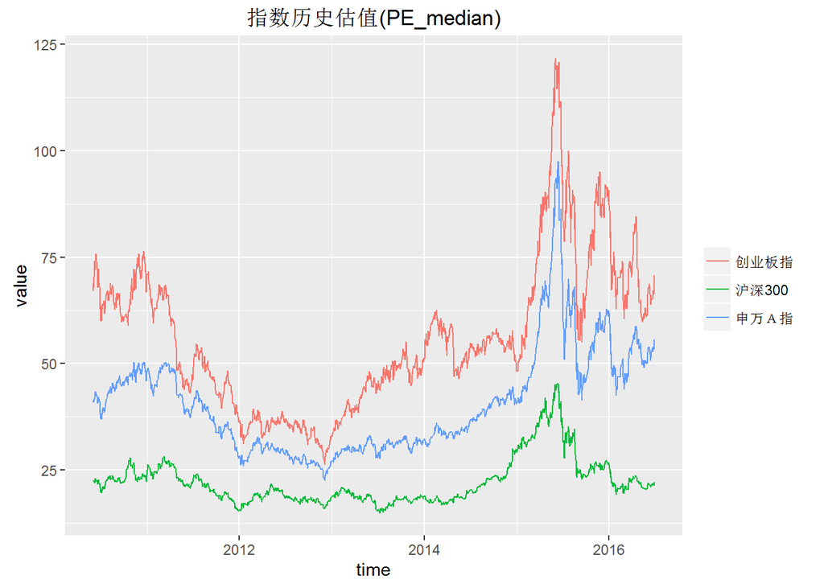

### (二)指数动态市盈率百分位

核心指数上述数据的百分位走势如下图所示：

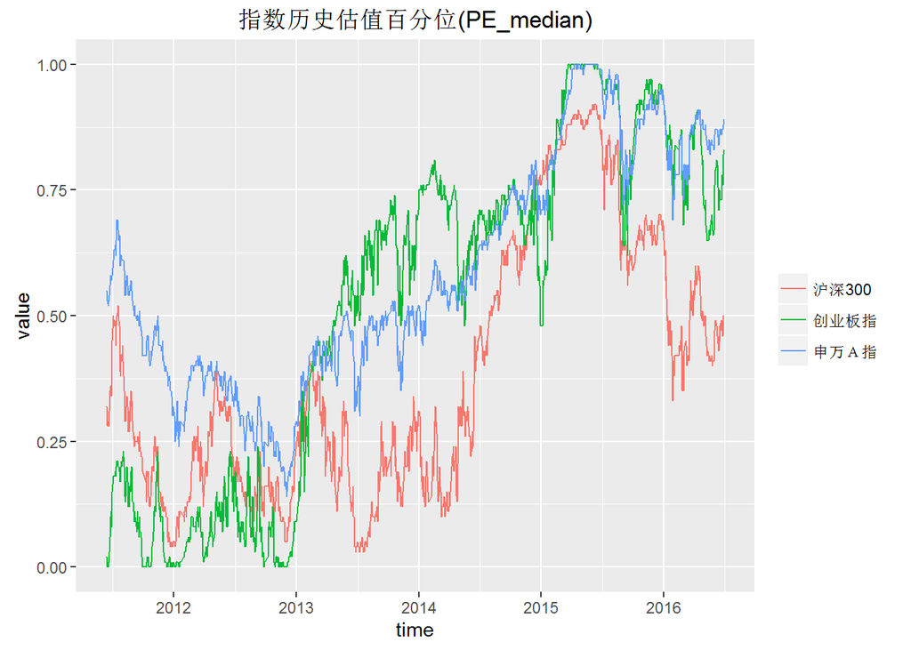

### (三)指数估值概览

纳入观察的18只指数最新的估值情况如下表：

| 日期 | 指数代码 | 指数简称 | 动态市盈率 | 上周动态市盈率 | 市盈率百分位 | 上周市盈率百分位 | 动态市净率 | 市净率百分位 |
| --- | --- | --- | --- | --- | --- | --- | --- | --- |
| 2016-06-28 | EI000979 | 大宗商品 | 45.23 | 43.86 | 0.93 | 0.91 | 2.55 | 0.48 |
| 2016-06-28 | EI000819 | 有色金属 | 62.14 | 57.27 | 0.91 | 0.87 | 4.09 | 0.86 |
| 2016-06-28 | EI801003 | 申万Ａ指 | 55.64 | 52.76 | 0.89 | 0.86 | 4.69 | 0.74 |
| 2016-06-28 | EI399959 | 军工指数 | 97.76 | 90.81 | 0.85 | 0.79 | 6.04 | 0.77 |
| 2016-06-28 | EI399005 | 中小板指P | 46.03 | 43.94 | 0.83 | 0.78 | 5.25 | 0.62 |
| 2016-06-28 | EI399006 | 创业板指 | 70.83 | 65.14 | 0.83 | 0.73 | 7.90 | 0.81 |
| 2016-06-28 | EI000805 | A股资源 | 43.58 | 42.73 | 0.82 | 0.82 | 2.40 | 0.51 |
| 2016-06-28 | EI000998 | 中证TMT | 60.77 | 56.63 | 0.80 | 0.74 | 6.03 | 0.77 |
| 2016-06-28 | EI801120 | 申万食品饮料 | 43.88 | 43.19 | 0.68 | 0.65 | 4.31 | 0.52 |
| 2016-06-28 | EI000933 | 中证医药 | 38.79 | 36.49 | 0.66 | 0.49 | 4.43 | 0.29 |
| 2016-06-28 | EI000905 | 中证500 | 39.56 | 38.56 | 0.63 | 0.60 | 3.53 | 0.56 |
| 2016-06-28 | EI000808 | 医药生物 | 40.41 | 38.52 | 0.62 | 0.43 | 5.33 | 0.57 |
| 2016-06-28 | EI399330 | 深证100 | 27.39 | 26.20 | 0.55 | 0.49 | 3.85 | 0.59 |
| 2016-06-28 | EI000300 | 沪深300 | 22.11 | 21.55 | 0.50 | 0.47 | 2.50 | 0.44 |
| 2016-06-28 | EI000827 | 中证环保 | 37.28 | 35.50 | 0.47 | 0.34 | 3.95 | 0.67 |
| 2016-06-28 | EI000932 | 中证消费 | 31.87 | 31.98 | 0.45 | 0.46 | 4.23 | 0.42 |
| 2016-06-28 | EI000934 | 中证金融 | 14.83 | 14.75 | 0.22 | 0.20 | 2.21 | 0.47 |
| 2016-06-28 | EI000016 | 上证50 | 11.66 | 11.62 | 0.06 | 0.06 | 1.46 | 0.03 |

## 二、基差

### (一)基差走势

三大股指期货隔季合约基差走势如下图：

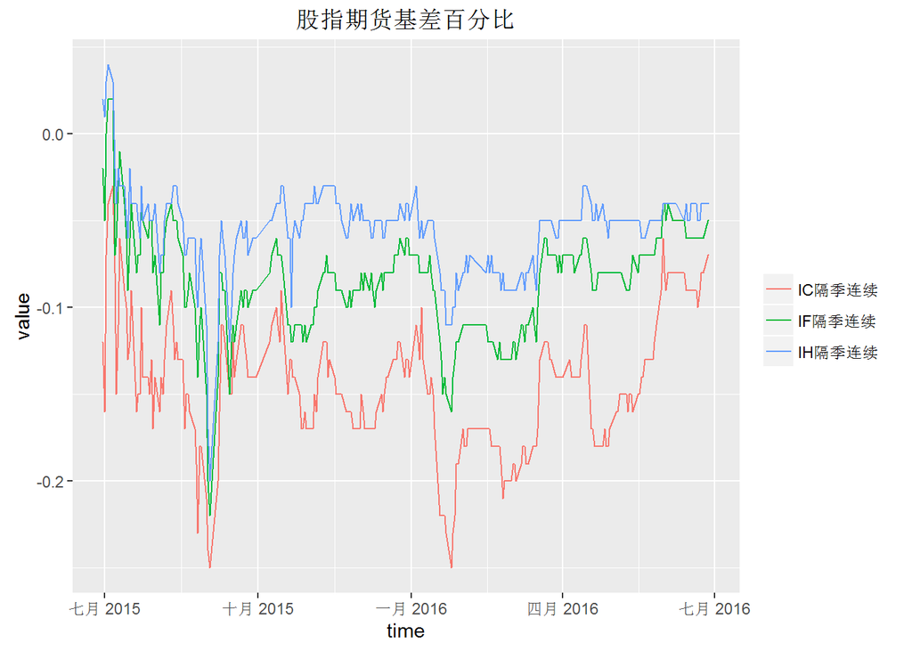

### (二)基差概况

三大股指期货连续合约基差概况如下表：

| 日期 | 合约简称 | 合约收盘价 | 基差 | 基差百分比 | 上周基差 | 上周基差百分比 |
| --- | --- | --- | --- | --- | --- | --- |
| 2016-06-28 | IH当月连续 | 2078.6 | -23.45 | -0.01 | -35.76 | -0.02 |
| 2016-06-28 | IH下月连续 | 2060.6 | -41.45 | -0.02 | -54.16 | -0.03 |
| 2016-06-28 | IH下季连续 | 2048.2 | -53.85 | -0.03 | -66.36 | -0.03 |
| 2016-06-28 | IH隔季连续 | 2014.6 | -87.45 | -0.04 | -97.56 | -0.05 |
| 2016-06-28 | IF当月连续 | 3094.0 | -42.40 | -0.01 | -68.52 | -0.02 |
| 2016-06-28 | IF下月连续 | 3055.6 | -80.80 | -0.03 | -108.52 | -0.03 |
| 2016-06-28 | IF下季连续 | 3032.8 | -103.60 | -0.03 | -138.92 | -0.04 |
| 2016-06-28 | IF隔季连续 | 2965.0 | -171.40 | -0.05 | -200.72 | -0.06 |
| 2016-06-28 | IC当月连续 | 6037.0 | -70.51 | -0.01 | -139.20 | -0.02 |
| 2016-06-28 | IC下月连续 | 5949.0 | -158.51 | -0.03 | -244.60 | -0.04 |
| 2016-06-28 | IC下季连续 | 5882.4 | -225.11 | -0.04 | -343.80 | -0.06 |
| 2016-06-28 | IC隔季连续 | 5676.4 | -431.11 | -0.07 | -593.80 | -0.10 |

## 三、套利

### (一)复牌股票套利

近两天复牌股票套利情况如下表：

[1] “无复牌股票套利”

### (二)定增基金跟踪

截止2016-06-29定增基金数据如下表，明细数据参见钱瀚的模板。

| 代码 | 名称 | 到期日期 | 最新净值 | 昨日收盘价 | 折溢价率 | 整体隐含折价率 | 大盘回撤0.1净值回撤 |
| --- | --- | --- | --- | --- | --- | --- | --- |
| 168101.OF | 九泰锐智 | 20200814 | 1.331 | 1.419 | 0.066 | 0.210 | -0.044 |
| 168102.OF | 九泰锐富 | 20210204 | 1.012 | 1.006 | -0.006 | 0.058 | -0.009 |
| 161222.OF | 国投瑞利 | 20160805 | 1.035 | 1.008 | -0.026 | 0.001 | -0.041 |
| 161225.OF | 国投瑞盈 | 20161119 | 0.990 | 0.977 | -0.013 | 0.072 | -0.071 |
| 501001.OF | 财通精选 | 20170101 | 1.046 | 0.960 | -0.082 | 0.032 | -0.090 |
| 501015.OF | 财通升级 | 20170908 | 1.018 | 0.943 | -0.074 | 0.078 | -0.020 |

定增基金近期的净值走势如下图：

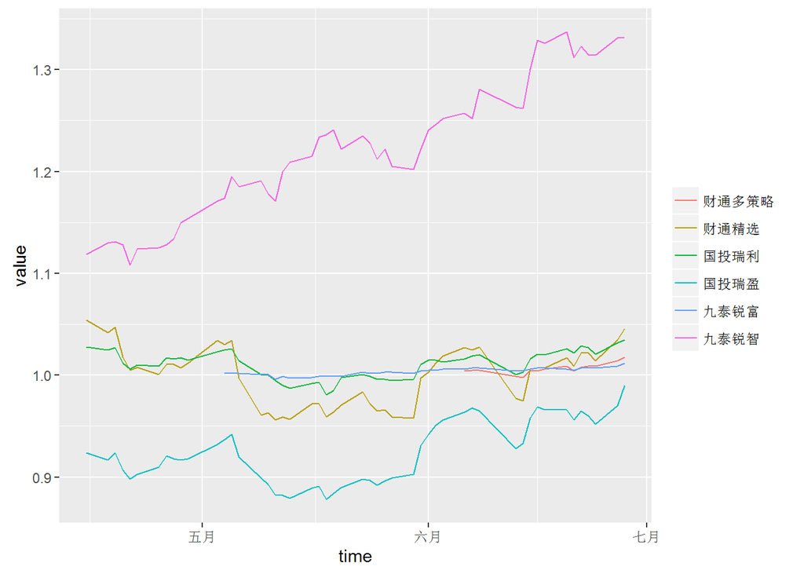

定增基金近期的折溢价走势如下图：

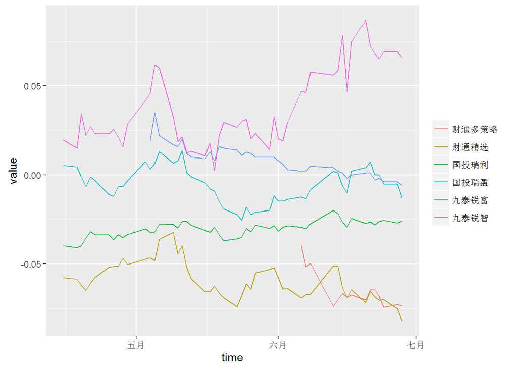

## 四、择时

### (一)大盘均线强弱指数

大盘均线强弱指数在一定程度上可以视为一个反转指标，当大盘均线得分接近8分时，预示市场接近顶部，当大盘均线得分接近0分时，预示市场接近底部。  
大盘均线强弱指数近一年来走势如下图：

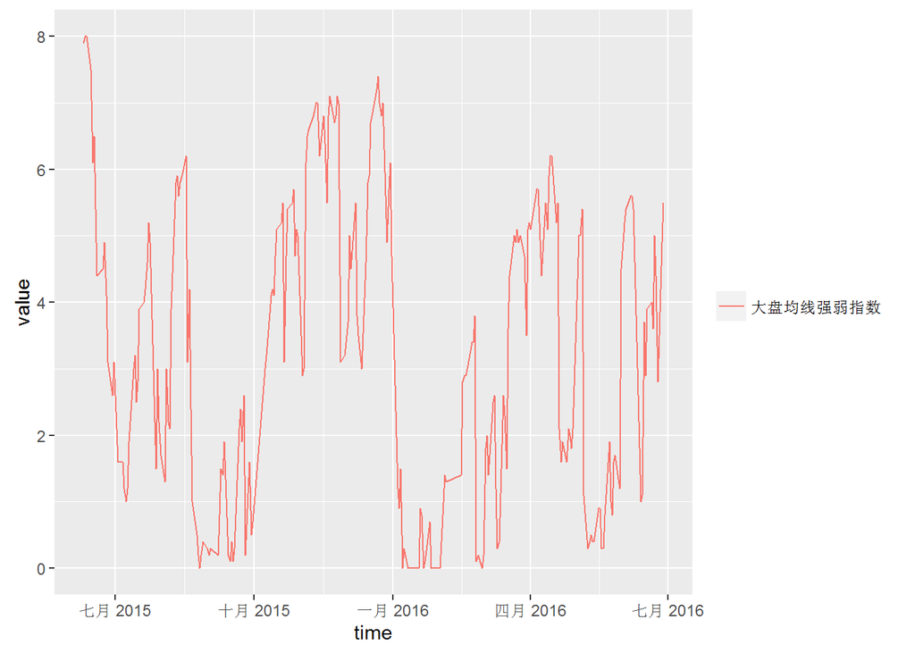

申万一级行业的最新得分及上周得分见下表：

| 日期 | 指数代码 | 指数名称 | 最新值 | 上周值 |
| --- | --- | --- | --- | --- |
| 2016-06-28 | EI801050 | 申万有色金属 | 8 | 7 |
| 2016-06-28 | EI801080 | 申万电子 | 8 | 8 |
| 2016-06-28 | EI801110 | 申万家用电器 | 8 | 6 |
| 2016-06-28 | EI801120 | 申万食品饮料 | 8 | 8 |
| 2016-06-28 | EI801880 | 申万汽车 | 8 | 8 |
| 2016-06-28 | EI801030 | 申万化工 | 7 | 6 |
| 2016-06-28 | EI801150 | 申万医药生物 | 7 | 4 |
| 2016-06-28 | EI801730 | 申万电气设备 | 7 | 6 |
| 2016-06-28 | EI801750 | 申万计算机 | 7 | 2 |
| 2016-06-28 | EI801770 | 申万通信 | 7 | 5 |
| 2016-06-28 | EI801010 | 申万农林牧渔 | 6 | 4 |
| 2016-06-28 | EI801140 | 申万轻工制造 | 6 | 5 |
| 2016-06-28 | EI801230 | 申万综合 | 6 | 3 |
| 2016-06-28 | EI801740 | 申万国防军工 | 6 | 6 |
| 2016-06-28 | EI801790 | 申万非银金融 | 6 | 4 |
| 2016-06-28 | EI801890 | 申万机械设备 | 6 | 6 |
| 2016-06-28 | EI801130 | 申万纺织服装 | 5 | 0 |
| 2016-06-28 | EI801710 | 申万建筑材料 | 5 | 3 |
| 2016-06-28 | EI801020 | 申万采掘 | 4 | 0 |
| 2016-06-28 | EI801160 | 申万公用事业 | 4 | 2 |
| 2016-06-28 | EI801180 | 申万房地产 | 4 | 1 |
| 2016-06-28 | EI801200 | 申万商业贸易 | 4 | 0 |
| 2016-06-28 | EI801210 | 申万休闲服务 | 4 | 0 |
| 2016-06-28 | EI801720 | 申万建筑装饰 | 4 | 1 |
| 2016-06-28 | EI801760 | 申万传媒 | 4 | 0 |
| 2016-06-28 | EI801040 | 申万钢铁 | 3 | 0 |
| 2016-06-28 | EI801170 | 申万交通运输 | 2 | 0 |
| 2016-06-28 | EI801780 | 申万银行 | 0 | 5 |

### (二)LLT及均线择时

LLT本质上是一个改进的单均线择时指标，较原始的均线择时延迟更低。  
择时模型和指数本身的净值走势如下图：

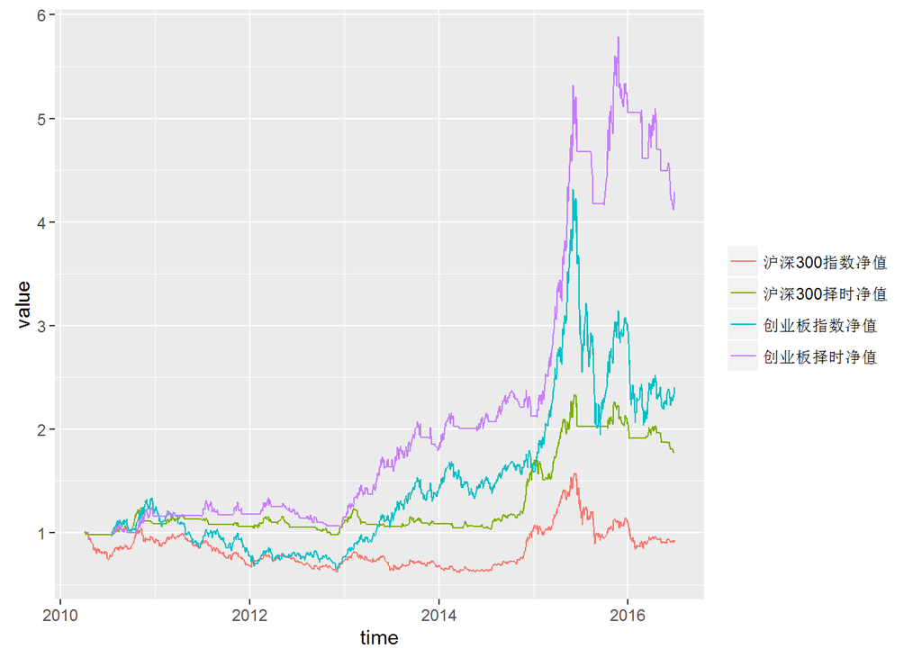

择时模型和指数的收益率统计如下表：

|  | 沪深300指 | 沪深300LLT | 创业板指 | 创业板MA |
| --- | --- | --- | --- | --- |
| 年化收益率 | -1.3 | 10.0 | 16.5 | 28.9 |
| 年化波动率 | 26.0 | 16.5 | 35.0 | 24.1 |
| 年化Sharpe值 | -5.0 | 60.9 | 47.2 | 119.9 |
| 最大回撤 | 46.7 | 24.0 | 54.9 | 28.9 |

择时模型最近10个交易日的信号如下表：

| 日期 | 沪深300收盘价 | 沪深300择时信号 | 创业板收盘价 | 创业板择时信号 |
| --- | --- | --- | --- | --- |
| 2016-06-15 | 3116.368 |  | 2128.799 | buy |
| 2016-06-16 | 3094.675 |  | 2101.416 | sell |
| 2016-06-17 | 3110.357 |  | 2122.890 | buy |
| 2016-06-20 | 3112.674 |  | 2119.630 | hold |
| 2016-06-21 | 3106.318 |  | 2092.001 | sell |
| 2016-06-22 | 3133.961 | buy | 2144.818 | buy |
| 2016-06-23 | 3117.317 | hold | 2137.485 | hold |
| 2016-06-24 | 3077.155 | sell | 2127.364 | hold |
| 2016-06-27 | 3120.544 |  | 2191.806 | hold |
| 2016-06-28 | 3136.401 | buy | 2216.710 | hold |

### (三)网格交易

在经历了三轮股灾，A股逐步回归正常，在过去的一段时间呈现一个震荡的格局，如果未来没有增量信息，很可能维持震荡。结合股指期货的贴水，前期研究了一下网格交易。网格交易的结果如下图：

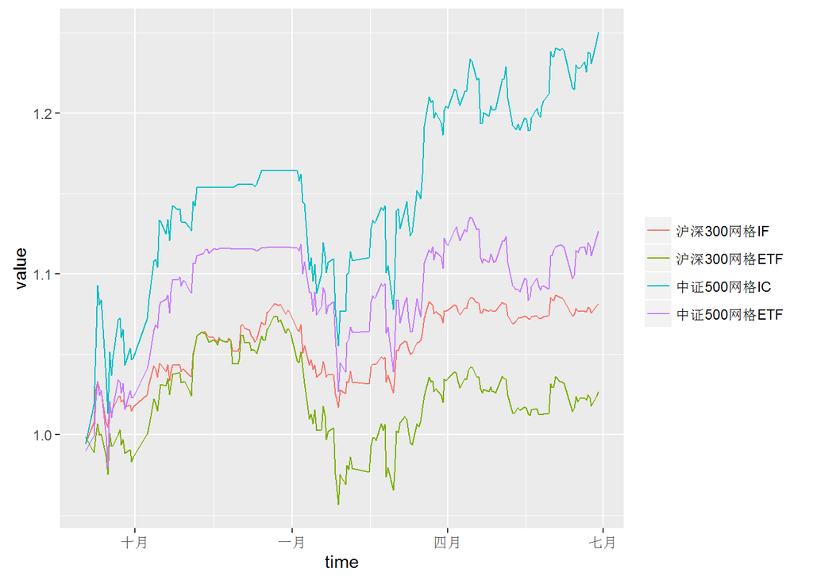

网格交易的收益统计如下表：

|  | 沪深300指数 | 沪深300网格IF | 沪深300网格ETF | 中证500指数 | 中证500网格IC | 中证500网格ETF |
| --- | --- | --- | --- | --- | --- | --- |
| 年化收益率 | -8.5 | 10.5 | 3.4 | -1.3 | 32.9 | 16.4 |
| 年化波动率 | 29.2 | 8.4 | 12.6 | 39.6 | 18.2 | 14.5 |
| 年化Sharpe值 | -29.0 | 125.9 | 27.4 | -3.2 | 180.6 | 112.9 |
| 最大回撤 | 26.4 | 5.9 | 10.9 | 33.5 | 9.4 | 8.2 |